# Power of hypothesis tests

## Packages

```r
library(tidyverse)
```

## Errors in testing

What can happen:

|  | Decision |  |
| --- | --- | --- |
| **Truth** | **Do not reject** | **Reject null** |
| **Null true** | Correct | Type I error |
| **Null false** | Type II error | Correct |

Tension between truth and decision about truth (imperfect).

## … continued

- Prob. of type I error denoted $\alpha$. Usually fix $\alpha$, eg. $\alpha = 0.05$.
- Prob. of type II error denoted $\beta$. Determined by the planned experiment. Low $\beta$ good.
- Prob. of not making type II error called **power** (= $1 - \beta$). *High* power good.

## Power 1/2

- Suppose $H_0 : \theta = 10$, $H_a : \theta \ne 10$ for some parameter $\theta$.
- Suppose $H_0$ wrong. What does that say about $\theta$?
- Not much. Could have $\theta = 11$ or $\theta = 8$ or $\theta = 496$. In each case, $H_0$ wrong.

## Power 2/2

- How likely a type II error is depends on what $\theta$ is:
  - If $\theta = 496$, should reject $H_0 : \theta = 10$ even for small sample, so $\beta$ small (power large).
  - If $\theta = 11$, hard to reject $H_0$ even with large sample, so $\beta$ would be larger (power smaller).
- Power depends on true parameter value, and on sample size.
- So we play “what if”: “if $\theta$ were 11 (or 8 or 496), what would power be?”.

## Figuring out power 1/2

- Time to figure out power is before you collect any data, as part of planning process.
- Need to have idea of what kind of departure from null hypothesis of interest to you, eg. average improvement of 5 points on reading test scores. (Subject-matter decision, not statistical one.)

## Figuring out power 2/2

- Then, either:
  - “I have this big a sample and this big a departure I want to detect. What is my power for detecting it?”
  - “I want to detect this big a departure with this much power. How big a sample size do I need?”

## How to understand/estimate power?

- Suppose we test $H_0 : \mu = 10$ against $H_a : \mu \ne 10$, where $\mu$ is population mean.
- Suppose in actual fact, $\mu = 8$, so $H_0$ is wrong. We want to reject it. How likely is that to happen?
- Need population SD (take $\sigma = 4$) and sample size (take $n = 15$). In practice, get $\sigma$ from pilot/previous study, and take the $n$ we plan to use.
- Idea: draw a random sample from the true distribution, test whether its mean is 10 or not.
- Repeat previous step “many” times: simulation.

## Making it go

- Random sample of 15 normal observations with mean 8 and SD 4:

```r
x <- rnorm(15, 8, 4)
x
```

```
 [1] 14.487469  5.014611  6.924277  5.201860  8.852952 10.835874  3.686684
 [8] 11.165242  8.016188 12.383518  1.378099  3.172503 13.074996 11.353573
[15]  5.015575
```

- Test whether `x` from population with mean 10 or not (over):

## …continued

```r
t.test(x, mu = 10)
```

```
    One Sample t-test

data:  x
t = -1.8767, df = 14, p-value = 0.08157
alternative hypothesis: true mean is not equal to 10
95 percent confidence interval:
  5.794735 10.280387
sample estimates:
mean of x
 8.037561
```

- P-value 0.081, so fail to reject the mean being 10 (a Type II error).

## or get just P-value

```r
ans <- t.test(x, mu = 10)
ans$p.value
```

```
[1] 0.0815652
```

## Run this lots of times via simulation

- draw random samples from the truth
- test that $\mu = 10$
- get P-value
- Count up how many of the P-values are 0.05 or less.

## In code

```r
tibble(sim = 1:1000) %>%
  rowwise() %>%
  mutate(my_sample = list(rnorm(15, 8, 4))) %>%
  mutate(t_test = list(t.test(my_sample, mu = 10))) %>%
  mutate(p_val = t_test$p.value) %>%
  count(p_val <= 0.05)
```

| p_val <= 0.05 | n |
| --- | --- |
| FALSE | 578 |
| TRUE | 422 |

We correctly rejected 422 times out of 1000, so the estimated power is 0.422.

## Try again with bigger sample

```r
tibble(sim = 1:1000) %>%
  rowwise() %>%
  mutate(my_sample = list(rnorm(40, 8, 4))) %>%
  mutate(t_test = list(t.test(my_sample, mu = 10))) %>%
  mutate(p_val = t_test$p.value) %>%
  count(p_val <= 0.05)
```

| p_val <= 0.05 | n |
| --- | --- |
| FALSE | 119 |
| TRUE | 881 |

Power is (much) larger with a bigger sample.

## How accurate is my simulation?

- At our chosen $\alpha$, each simulated test independently either rejects or not with some probability $p$ that I am trying to estimate (the power)
- Estimating a population probability using the sample proportion (the number of simulated rejections out of the number of simulated tests)
- hence, `prop.test`.
- inputs: number of rejections, number of simulations.

## Sample size 15, rejected 422 times

```r
prop.test(422, 1000)
```

```
    1-sample proportions test with continuity correction

data:  422 out of 1000, null probability 0.5
X-squared = 24.025, df = 1, p-value = 9.509e-07
alternative hypothesis: true p is not equal to 0.5
95 percent confidence interval:
 0.3912521 0.4533546
sample estimates:
    p
0.422
```

95% CI for power: 0.391 to 0.453

## To estimate power more accurately

- Run more *simulations*:

Change 1000 to eg 10,000:

```r
tibble(sim = 1:10000) %>%
  rowwise() %>%
  mutate(my_sample = list(rnorm(15, 8, 4))) %>%
  mutate(t_test = list(t.test(my_sample, mu = 10))) %>%
  mutate(p_val = t_test$p.value) %>%
  count(p_val <= 0.05)
```

| p_val <= 0.05 | n |
| --- | --- |
| FALSE | 5647 |
| TRUE | 4353 |

## Accuracy of power now

```r
prop.test(4353, 10000)
```

```
    1-sample proportions test with continuity correction

data:  4353 out of 10000, null probability 0.5
X-squared = 167.18, df = 1, p-value < 2.2e-16
alternative hypothesis: true p is not equal to 0.5
95 percent confidence interval:
 0.4255594 0.4450905
sample estimates:
     p
0.4353
```

0.426 to 0.445, about factor $\sqrt{10}$ shorter because number of simulations 10 times bigger.

## Calculating power 1/2

- Simulation approach very flexible: will work for any test. But answer different each time because of randomness.
- In some cases, for example 1-sample and 2-sample t-tests, power can be calculated.
- `power.t.test`.

## Calculating power 2/2

- Input `delta` is difference between null and true mean:

```r
power.t.test(n = 15, delta = 10-8, sd = 4, type = "one.sample")
```

```
     One-sample t test power calculation

              n = 15
          delta = 2
             sd = 4
      sig.level = 0.05
          power = 0.4378466
    alternative = two.sided
```

## Comparison of results

| Method | Power |
| --- | --- |
| Simulation (10000) | 0.4353 |
| **`power.t.test`** | 0.4378 |

- Simulation power is similar to calculated power; to get more accurate value, repeat more times (eg. 100,000 instead of 10,000), which takes longer.
- With this small a sample size, the power is not great. With a bigger sample, the sample mean should be closer to 8 most of the time, so would reject $H_0 : \mu = 10$ more often.

## Calculating required sample size

- Often, when planning a study, we do not have a particular sample size in mind. Rather, we want to know how big a sample to take. This can be done by asking how big a sample is needed to achieve a certain power.
- The simulation approach does not work naturally with this, since you have to supply a sample size.
  - For that, you try different sample sizes until you get power close to what you want.
- For the power-calculation method, you supply a value for the power, but leave the sample size missing.

## Using power.t.test

- Re-use the same problem: $H_0 : \mu = 10$ against 2-sided alternative, true $\mu = 8$, $\sigma = 4$, but now aim for power 0.80.
- No `n=`, replaced by a `power=`:

```r
power.t.test(power=0.80, delta=10-8, sd=4, type="one.sample")
```

```
     One-sample t test power calculation

              n = 33.3672
          delta = 2
             sd = 4
      sig.level = 0.05
          power = 0.8
    alternative = two.sided
```

- Sample size must be a whole number, so round up to 34 (to get at least as much power as you want).

## Power curves

- Rather than calculating power for one sample size, or sample size for one power, might want a picture of relationship between sample size and power.
- Or, likewise, picture of relationship between difference between true and null-hypothesis means and power.
- Called power curve.
- Build and plot it yourself.

## Building it:

```r
tibble(n=seq(10, 100, 10)) %>% rowwise() %>%
  mutate(power_output =
           list(power.t.test(n = n, delta = 10-8, sd = 4,
                             type = "one.sample"))) %>%
  mutate(power = power_output$power) %>%
  ggplot(aes(x=n, y=power)) + geom_point() + geom_line() +
    geom_hline(yintercept=1, linetype="dashed") -> g2
```

## The power curve

```r
g2
```

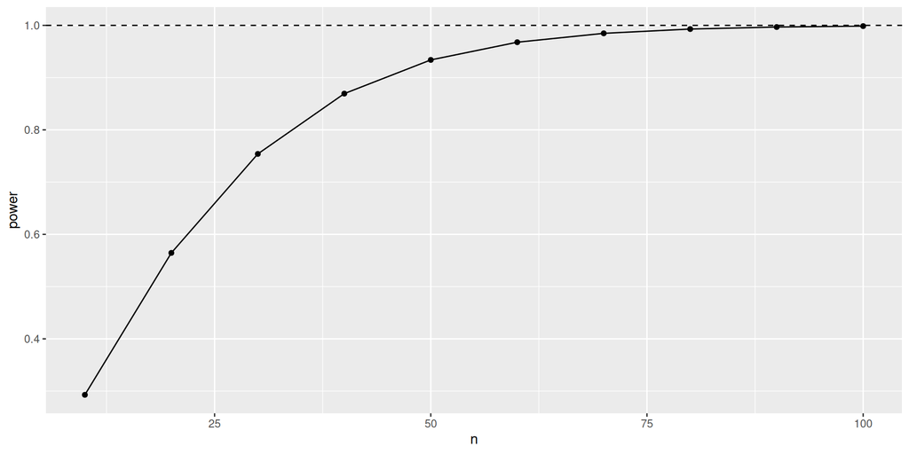

## Power curves for means

- Can also investigate power as it depends on what the true mean is (the farther from null mean 10, the higher the power will be).
- Investigate for two different sample sizes, 15 and 30.
- First make all combos of mean and sample size:

```r
means <- seq(6,10,0.5)
ns <- c(15,30)
combos <- crossing(mean=means, n=ns)
```

## The combos

```r
combos
```

| mean | n |
| --- | --- |
| 6.0 | 15 |
| 6.0 | 30 |
| 6.5 | 15 |
| 6.5 | 30 |
| 7.0 | 15 |
| 7.0 | 30 |
| 7.5 | 15 |
| 7.5 | 30 |
| 8.0 | 15 |
| 8.0 | 30 |

[output cut: 8 more lines]

## Calculate powers:

```r
combos %>%
  rowwise() %>%
  mutate(power_stuff = list(power.t.test(n=n, delta=10-mean, sd=4,
                              type="one.sample"))) %>%
  mutate(power = power_stuff$power) -> powers
```

## then make the plot:

```r
g  <-  ggplot(powers, aes(x = mean, y = power, colour = factor(n))) +
  geom_point() + geom_line() +
  geom_hline(yintercept = 1, linetype = "dashed") +
  geom_vline(xintercept = 10, linetype = "dotted")
```

- Need `n` as categorical so that `colour` works properly.

## The power curves

```r
g
```

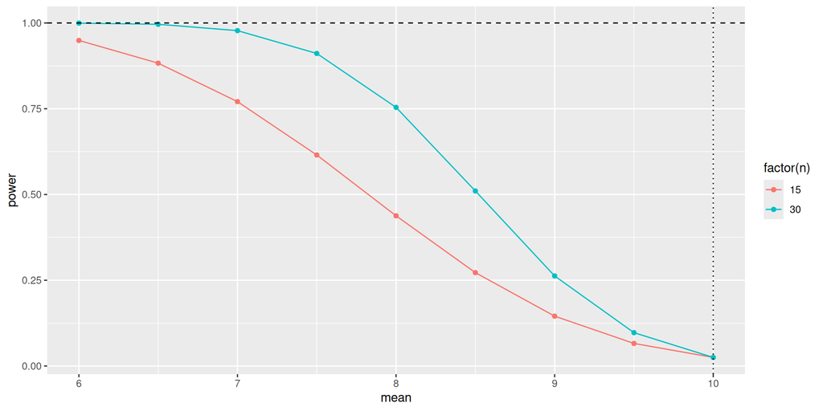

## Two-sample power

- For kids learning to read, had sample sizes of 22 (approx) in each group
- and these group SDs:

```r
kids %>% group_by(group) %>%
  summarize(n=n(), s=sd(score))
```

| group | n | s |
| --- | --- | --- |
| c | 23 | 17.14873 |
| t | 21 | 11.00736 |

## Setting up

- suppose a 5-point improvement in reading score was considered important (on this scale)
- in a 2-sample test, null (difference of) mean is zero, so `delta` is true difference in means
- what is power for these sample sizes, and what sample size would be needed to get power up to 0.80?
- SD in both groups has to be same in `power.t.test`, so take as 14.

## Calculating power for sample size 22 (per group)

```r
power.t.test(n=22, delta=5, sd=14, type="two.sample",
             alternative="one.sided")
```

```
     Two-sample t test power calculation

              n = 22
          delta = 5
             sd = 14
      sig.level = 0.05
          power = 0.3158199
    alternative = one.sided

NOTE: n is number in *each* group
```

## sample size for power 0.8

```r
power.t.test(power=0.80, delta=5, sd=14, type="two.sample",
             alternative="one.sided")
```

```
     Two-sample t test power calculation

              n = 97.62598
          delta = 5
             sd = 14
      sig.level = 0.05
          power = 0.8
    alternative = one.sided

NOTE: n is number in *each* group
```

## Comments

- The power for the sample sizes we have is very small (to detect a 5-point increase).
- To get power 0.80, we need 98 kids in *each* group!